# Evolutionary Genomics Lab 4

## Data Analysis and Visualization in Python for Ecologists

The following lessons are from the [DataCarpentry](https://datacarpentry.org/python-ecology-lesson/) website. They include:

- Lesson 6: Making Plots with plotnine
- Lesson 7: Data Ingest and Visualization - Matplotlib and Pandas
- Lesson 8: Accessing SQLite Databases Using Python and Pandas

### Lesson 6: Making Plots with plotnine

**Lesson Questions**

- How can I visualize data in Python?
- What is 'grammar of graphics'?

**Lesson Objectives**

- Create a plotnine object.
- Set universal plot settings.
- Modify an existing plotnine object.
- Change the aesthetics of a plot such as color.
- Edit the axis labels.
- Build complex plots using a step-by-step approach.
- Create scatter plots, box plots, and time series plots.
- Use the facet_wrap and facet_grid commands to create a collection of plots splitting the data by a factor variable.
- Create customized plot styles to meet their needs.

```python
# Set working directory

import os
os.chdir('/Users/greg/Box/courses/umass/fall-2020/evolutionary-genomics-and-bioinformatics/evo-geno-course/')
os.getcwd()
```

```
'/Users/greg/Box/courses/umass/fall-2020/evolutionary-genomics-and-bioinformatics/evo-geno-course'
```

*The [plotnine](https://plotnine.readthedocs.io/en/stable/) package "facilitates the creation of highly-informative plots of structured data based on the R implementation of ggplot2 and [The Grammar of Graphics](https://link.springer.com/book/10.1007%2F0-387-28695-0) by Leland Wilkinson. The plotnine package is built on top of Matplotlib and interacts well with Pandas."*

```python
%matplotlib inline
import plotnine as p9
```

```python
import pandas as pd
surveys_complete = pd.read_csv('data/lab-3-data/surveys.csv')
surveys_complete = surveys_complete.dropna()
```

#### Plotting with plotnine

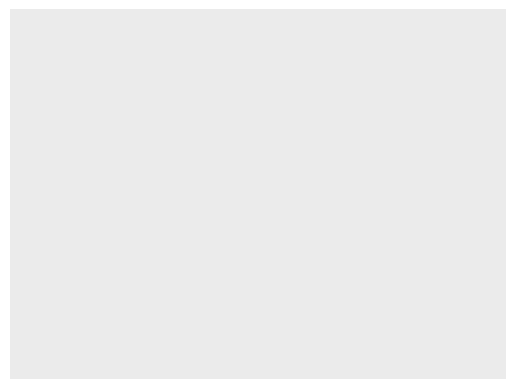

```python
(p9.ggplot(surveys_complete))
```

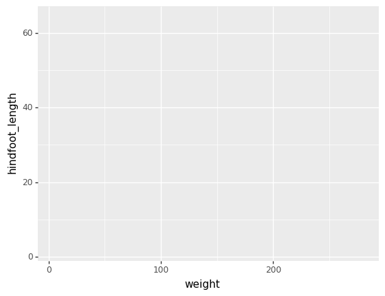

```python
(p9.ggplot(surveys_complete, p9.aes(x='weight', y='hindfoot_length')))
```

```python
(p9.ggplot(surveys_complete, p9.aes(x='weight', y='hindfoot_length'))
    + p9.geom_point()
)
```

[output not shown]

```python
# Create
surveys_plot = p9.ggplot(surveys_complete,
                         p9.aes(x='weight', y='hindfoot_length'))

# Draw the plot
surveys_plot + p9.geom_point()
```

[output not shown]

**Challenge - bar chart** Working on the surveys_complete data set, use the plot-id column to create a bar-plot that counts the number of records for each plot. (Check the documentation of the bar geometry to handle the counts)

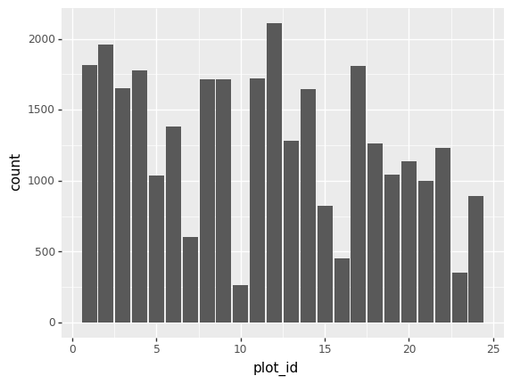

```python
(p9.ggplot(surveys_complete, p9.aes(x='plot_id')) +
    p9.geom_bar(stat="count")
)
```

#### Building your plots iteratively

```python
(p9.ggplot(surveys_complete, p9.aes(x='weight', y='hindfoot_length')) +
     p9.geom_point()
)
```

[output not shown]

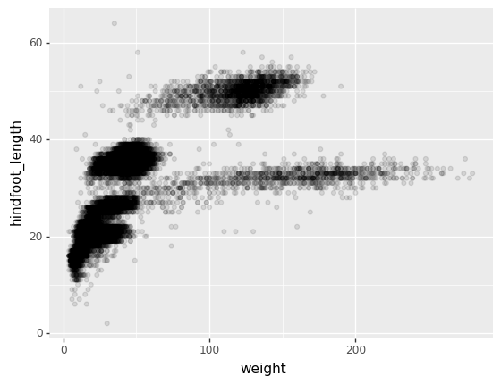

```python
(p9.ggplot(surveys_complete, p9.aes(x='weight', y='hindfoot_length'))
    + p9.geom_point(alpha=0.1)
)
```

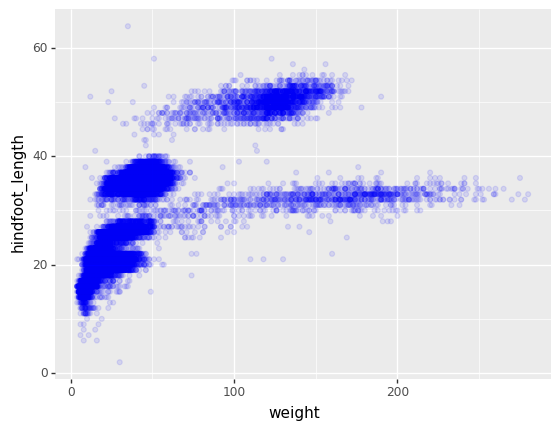

```python
(p9.ggplot(surveys_complete, p9.aes(x='weight', y='hindfoot_length'))
    + p9.geom_point(alpha=0.1, color='blue')
)
```

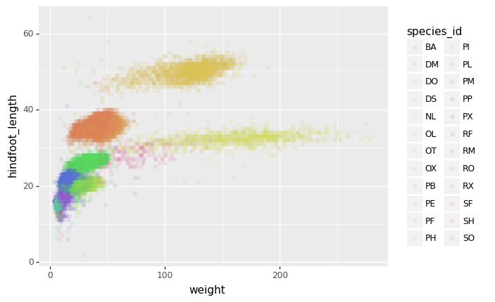

```python
(p9.ggplot(surveys_complete, p9.aes(x='weight',
                          y='hindfoot_length',
                          color='species_id'))
    + p9.geom_point(alpha=0.1)
)
```

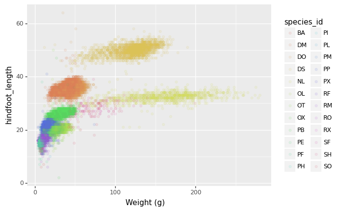

```python
(p9.ggplot(surveys_complete, p9.aes(x='weight', y='hindfoot_length', color='species_id'))
    + p9.geom_point(alpha=0.1)
    + p9.xlab("Weight (g)")
)
```

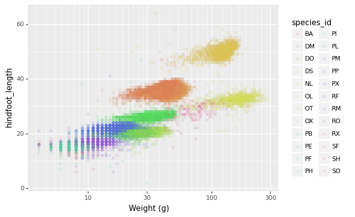

```python
(p9.ggplot(surveys_complete, p9.aes(x='weight', y='hindfoot_length', color='species_id'))
    + p9.geom_point(alpha=0.1)
    + p9.xlab("Weight (g)")
    + p9.scale_x_log10()
)
```

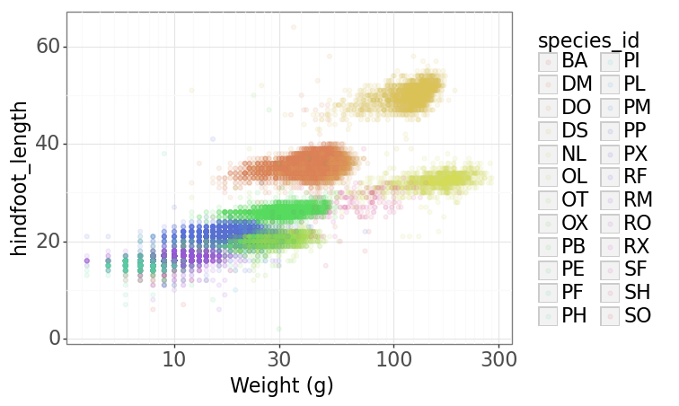

```python
(p9.ggplot(surveys_complete, p9.aes(x='weight', y='hindfoot_length', color='species_id'))
    + p9.geom_point(alpha=0.1)
    + p9.xlab("Weight (g)")
    + p9.scale_x_log10()
    + p9.theme_bw()
    + p9.theme(text=p9.element_text(size=16))
)
```

**Challenge - Bar plot adaptations** Adapt the bar plot of the previous exercise by mapping the sex variable to the color fill of the bar chart. Change the scale of the color fill by providing the colors blue and orange manually (see API reference to find the appropriate function).

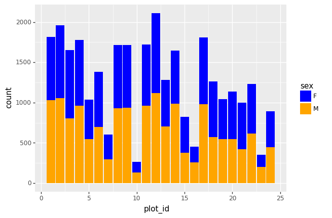

```python
(p9.ggplot(surveys_complete, p9.aes(x='plot_id', fill='sex')) +
    p9.geom_bar(stat="count") +
    p9.scale_fill_manual(["blue","orange"])
)
```

### Plotting distributions

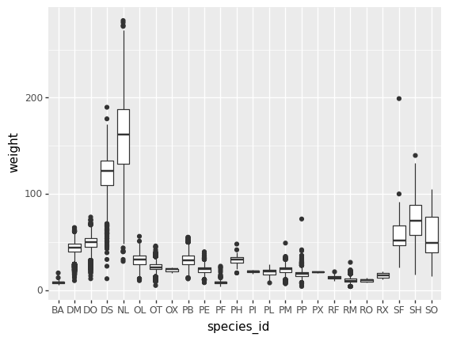

```python
(p9.ggplot(surveys_complete, p9.aes(x='species_id', y='weight'))
    + p9.geom_boxplot()
)
```

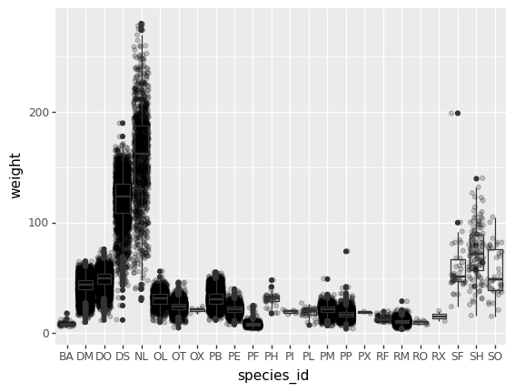

```python
(p9.ggplot(surveys_complete, p9.aes(x='species_id', y='weight'))
    + p9.geom_jitter(alpha=0.2)
    + p9.geom_boxplot(alpha=0.)
)
```

**Challenge - distributions** In many types of data, it is important to consider the scale of the observations. For example, it may be worth changing the scale of the axis to better distribute the observations in the space of the plot.

- Replace the box plot with a violin plot, see geom_violin()
- Represent weight on the log10 scale, see scale_y_log10()
- Add color to the datapoints on your boxplot according to the plot from which the sample was taken (plot_id)

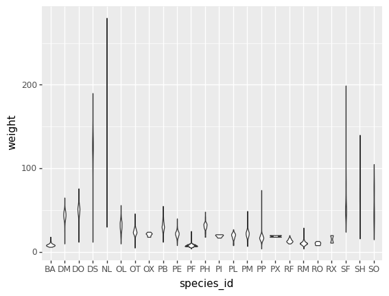

```python
(p9.ggplot(surveys_complete, p9.aes(x='species_id', y='weight'))
    + p9.geom_violin()
)
```

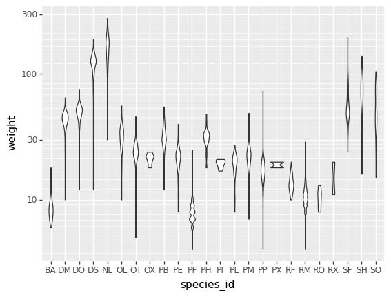

```python
(p9.ggplot(surveys_complete, p9.aes(x='species_id', y='weight'))
    + p9.geom_violin()
    + p9.scale_y_log10()
)
```

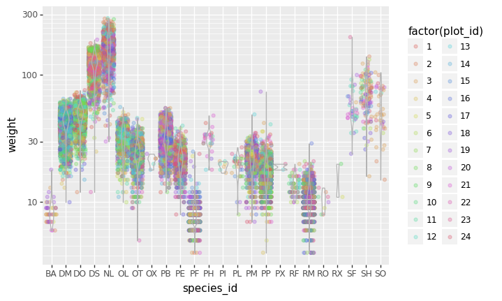

```python
(p9.ggplot(surveys_complete, p9.aes(x='species_id', y='weight', color='factor(plot_id)'))
    + p9.geom_jitter(alpha=0.3)
    + p9.geom_violin(alpha=0, color="0.7")
    + p9.scale_y_log10()
)
```

### Plotting time series data

```python
# Calculate number of counts per year for each species
yearly_counts = surveys_complete.groupby(['year', 'species_id'])['species_id'].count()
yearly_counts
```

```
year  species_id
1977  DM            181
      DO             12
      DS             29
      OL              1
      OX              2
                   ...
2002  PP            375
      RM             20
      RO              7
      SF              5
      SH              9
Name: species_id, Length: 332, dtype: int64
```

```python
# Reset index to use both year and species_id as column variable
yearly_counts = yearly_counts.reset_index(name='counts')
yearly_counts
```

|  | year | species_id | counts |
| --- | --- | --- | --- |
| 0 | 1977 | DM | 181 |
| 1 | 1977 | DO | 12 |
| 2 | 1977 | DS | 29 |
| 3 | 1977 | OL | 1 |
| 4 | 1977 | OX | 2 |
| ... | ... | ... | ... |
| 327 | 2002 | PP | 375 |
| 328 | 2002 | RM | 20 |
| 329 | 2002 | RO | 7 |
| 330 | 2002 | SF | 5 |
| 331 | 2002 | SH | 9 |

332 rows × 3 columns

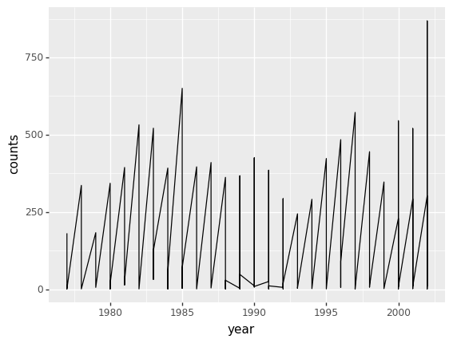

```python
(p9.ggplot(data=yearly_counts, mapping=p9.aes(x='year', y='counts'))
    + p9.geom_line()
)
```

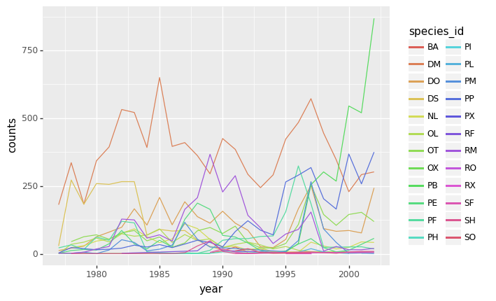

```python
(p9.ggplot(data=yearly_counts, mapping=p9.aes(x='year', y='counts', color='species_id'))
    + p9.geom_line()
)
```

### Faceting

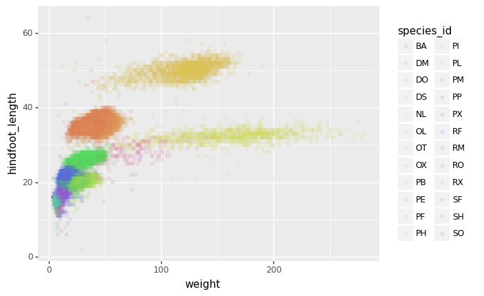

```python
(p9.ggplot(surveys_complete, p9.aes(x='weight', y='hindfoot_length', color='species_id'))
    + p9.geom_point(alpha=0.1)
)
```

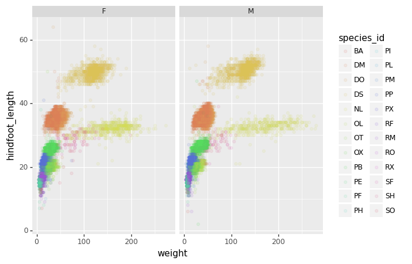

```python
(p9.ggplot(surveys_complete, p9.aes(x='weight', y='hindfoot_length', color='species_id'))
    + p9.geom_point(alpha=0.1)
    + p9.facet_wrap("sex")
)
```

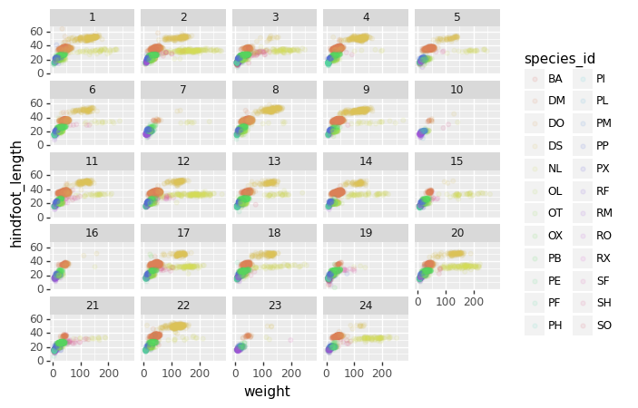

```python
(p9.ggplot(surveys_complete, p9.aes(x='weight', y='hindfoot_length', color='species_id'))
    + p9.geom_point(alpha=0.1)
    + p9.facet_wrap("plot_id")
)
```

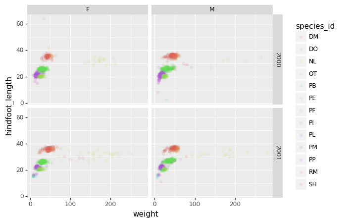

```python
# only select the years of interest
survey_2000 = surveys_complete[surveys_complete["year"].isin([2000, 2001])]

(p9.ggplot(survey_2000, p9.aes(x='weight', y='hindfoot_length', color='species_id'))
    + p9.geom_point(alpha=0.1)
    + p9.facet_grid("year ~ sex")
)
```

**Challenge - facetting**

- Create a separate plot for each of the species that depicts how the average weight of the species changes through the years.

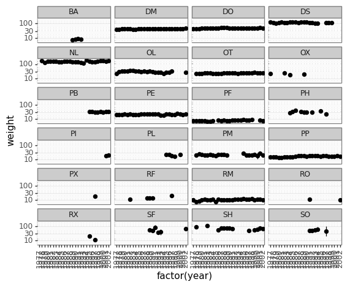

```python
(p9.ggplot(surveys_complete, p9.aes(x='factor(year)', y='weight'))
    + p9.stat_summary()
    + p9.scale_y_log10()
    + p9.facet_wrap("species_id", ncol=4)
    + p9.theme_bw()
    + p9.theme(axis_text_x = p9.element_text(angle=90))
)
```

**Challenge - facetting**

- Based on the previous exercise, visually compare how the weights of male and females has changed through time by creating a separate plot for each sex and an individual color assigned to each species_id.

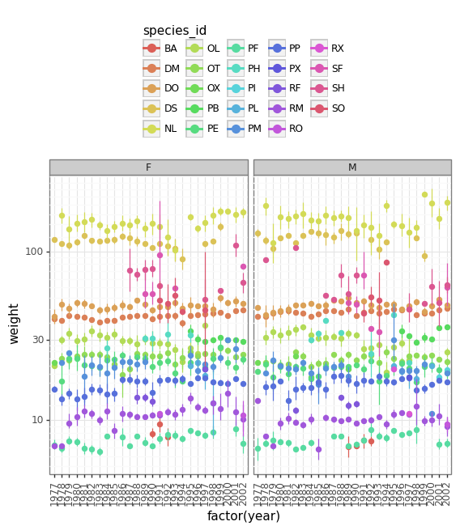

```python
(p9.ggplot(surveys_complete, p9.aes(x='factor(year)', y='weight', color='species_id'))
    + p9.stat_summary()
    + p9.facet_wrap('sex')
    + p9.scale_y_log10()
    + p9.theme_bw()
    + p9.theme(axis_text_x = p9.element_text(angle=90),
               legend_position = 'top')
)
```

### Further customization

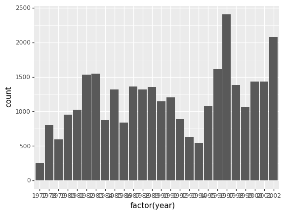

```python
(p9.ggplot(surveys_complete, p9.aes(x='factor(year)'))
    + p9.geom_bar()
)
```

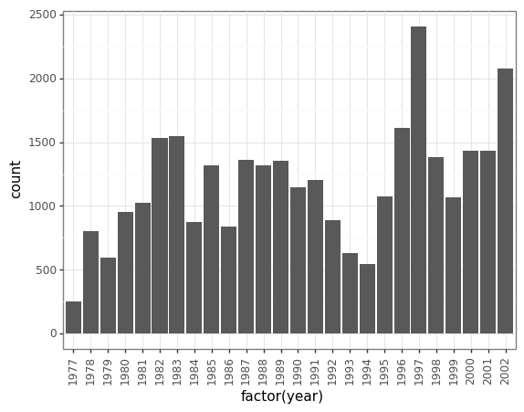

```python
(p9.ggplot(surveys_complete, p9.aes(x='factor(year)'))
    + p9.geom_bar()
    + p9.theme_bw()
    + p9.theme(axis_text_x = p9.element_text(angle=90))
)
```

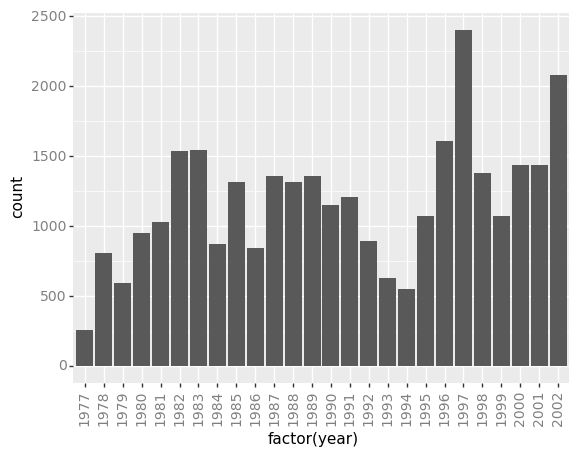

```python
my_custom_theme = p9.theme(axis_text_x = p9.element_text(color="grey", size=10,
                                                         angle=90, hjust=.5),
                           axis_text_y = p9.element_text(color="grey", size=10))
(p9.ggplot(surveys_complete, p9.aes(x='factor(year)'))
    + p9.geom_bar()
    + my_custom_theme
)
```

**Challenge - customization**

Please take another five minutes to either improve one of the plots generated in this exercise or create a beautiful graph of your own.

Here are some ideas:

- See if you can change thickness of lines for the line plot .
- Can you find a way to change the name of the legend? What about its labels?
- Use a different color palette (see http://www.cookbook-r.com/Graphs/Colors_(ggplot2))

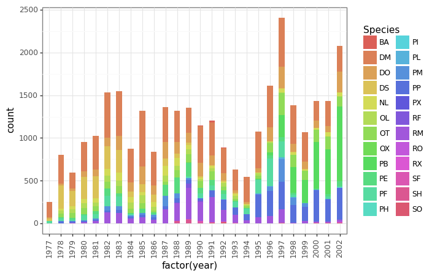

```python
(p9.ggplot(surveys_complete, p9.aes(x='factor(year)', fill='species_id'))
    + p9.geom_bar(width=0.5)
    + p9.labs(fill = "Species")
    + p9.theme_bw()
    + p9.theme(axis_text_x = p9.element_text(angle=90))
)
```

```python
# Saving plots as png file

my_plot = (p9.ggplot(surveys_complete, p9.aes(x='weight', y='hindfoot_length'))
    + p9.geom_point()
)

my_plot.save("figures/scatterplot.png", width=10, height=10, dpi=300)
```

**Key Points from Lesson 6: Making Plots with plotnine**

- The data, aes variables and a geometry are the main elements of a plotnine graph
- With the + operator, additional scale*, theme*, xlab/ylab and facet_* elements are added

### Lesson 7: Data Ingest and Visualization - Matplotlib and pandas

**Lesson Questions**

- what other tools can I use to create plots apart from ggplot?
- why should I use Python to create plots?

**Lesson Objectives**

- Import the pyplot toolbox to create figures in Python.
- Use matplotlib to make adjustments to Pandas or plotnine objects.

```python
# Set working directory

import os
os.chdir('/Users/greg/Box/courses/umass/fall-2020/evolutionary-genomics-and-bioinformatics/evo-geno-course/')
os.getcwd()
```

```
'/Users/greg/Box/courses/umass/fall-2020/evolutionary-genomics-and-bioinformatics/evo-geno-course'
```

#### Obtain data

*There are many repositories online from which you can obtain data. We are providing you with one data file to use with these exercises, but feel free to use any data that is relevant to your research. The file **bouldercreek_09_2013.txt** contains stream discharge data, summarized at 15 minute intervals (in cubic feet per second) for a streamgage on Boulder Creek at North 75th Street (USGS gage06730200) for 1-30 September 2013. If you’d like to use this dataset, please find it in the data folder.*

```python
import pandas as pd
boulder = pd.read_csv('data/lab-3-data/bouldercreek_09_2013.txt',
                      delimiter='\t', skiprows=25)
boulder
```

|  | agency_cd | site_no | datetime | tz_cd | 04_00060 | 04_00060_cd |
| --- | --- | --- | --- | --- | --- | --- |
| 0 | 5s | 15s | 20d | 6s | 14n | 10s |
| 1 | USGS | 06730200 | 2013-09-01 00:00 | MDT | 57 | A |
| 2 | USGS | 06730200 | 2013-09-01 00:15 | MDT | 57 | A |
| 3 | USGS | 06730200 | 2013-09-01 00:30 | MDT | 57 | A |
| 4 | USGS | 06730200 | 2013-09-01 00:45 | MDT | 57 | A |
| ... | ... | ... | ... | ... | ... | ... |
| 2871 | USGS | 06730200 | 2013-09-30 22:45 | MDT | 334 | A |
| 2872 | USGS | 06730200 | 2013-09-30 23:00 | MDT | 334 | A |
| 2873 | USGS | 06730200 | 2013-09-30 23:15 | MDT | 334 | A |
| 2874 | USGS | 06730200 | 2013-09-30 23:30 | MDT | 334 | A |
| 2875 | USGS | 06730200 | 2013-09-30 23:45 | MDT | 339 | A |

2876 rows × 6 columns

*If you are still having trouble importing the data as a table using Pandas, check the documentation. You can open the docstring in an ipython notebook using a question mark.*

```python
pd.read_csv?
```

*Common delimiters are **','** for comma, **' '** for space, and **'\t'** for tab.*

#### Clean up your data and open it using Python and Pandas

*Create a DataFrame that includes only the values of the data that are useful to you. In the streamgage file, those values might be the date, time, and discharge measurements. Convert any measurements in imperial units into SI units. You can also change the name of the columns in the DataFrame like this:*

```python
df = pd.DataFrame({'1stcolumn':[100,200], '2ndcolumn':[10,20]}) # this just creates a DataFrame for the example!
print('With the old column names:\n') # the \n makes a new line, so it's easier to see
print(df)

df.columns = ['FirstColumn', 'SecondColumn'] # rename the columns!
print('\n\nWith the new column names:\n')
print(df)
```

```
With the old column names:

   1stcolumn  2ndcolumn
0        100         10
1        200         20


With the new column names:

   FirstColumn  SecondColumn
0          100            10
1          200            20
```

```python
useful_boulder = boulder[1: ][['datetime','04_00060']] # Remove first row and select datetime and discharge columns
useful_boulder
```

|  | datetime | 04_00060 |
| --- | --- | --- |
| 1 | 2013-09-01 00:00 | 57 |
| 2 | 2013-09-01 00:15 | 57 |
| 3 | 2013-09-01 00:30 | 57 |
| 4 | 2013-09-01 00:45 | 57 |
| 5 | 2013-09-01 01:00 | 57 |
| ... | ... | ... |
| 2871 | 2013-09-30 22:45 | 334 |
| 2872 | 2013-09-30 23:00 | 334 |
| 2873 | 2013-09-30 23:15 | 334 |
| 2874 | 2013-09-30 23:30 | 334 |
| 2875 | 2013-09-30 23:45 | 339 |

2875 rows × 2 columns

**Note: 04_00060 stands for discharge. Discharge is measured in cubic feet per second.**

```python
useful_boulder.columns = ['datetime', 'discharge_imperial'] # rename column titles
useful_boulder
```

|  | datetime | discharge_imperial |
| --- | --- | --- |
| 1 | 2013-09-01 00:00 | 57 |
| 2 | 2013-09-01 00:15 | 57 |
| 3 | 2013-09-01 00:30 | 57 |
| 4 | 2013-09-01 00:45 | 57 |
| 5 | 2013-09-01 01:00 | 57 |
| ... | ... | ... |
| 2871 | 2013-09-30 22:45 | 334 |
| 2872 | 2013-09-30 23:00 | 334 |
| 2873 | 2013-09-30 23:15 | 334 |
| 2874 | 2013-09-30 23:30 | 334 |
| 2875 | 2013-09-30 23:45 | 339 |

2875 rows × 2 columns

```python
useful_boulder['discharge_si'] = useful_boulder['discharge_imperial'].astype('float64') * (1/3.3)
useful_boulder
```

|  | datetime | discharge_imperial | discharge_si |
| --- | --- | --- | --- |
| 1 | 2013-09-01 00:00 | 57 | 17.272727 |
| 2 | 2013-09-01 00:15 | 57 | 17.272727 |
| 3 | 2013-09-01 00:30 | 57 | 17.272727 |
| 4 | 2013-09-01 00:45 | 57 | 17.272727 |
| 5 | 2013-09-01 01:00 | 57 | 17.272727 |
| ... | ... | ... | ... |
| 2871 | 2013-09-30 22:45 | 334 | 101.212121 |
| 2872 | 2013-09-30 23:00 | 334 | 101.212121 |
| 2873 | 2013-09-30 23:15 | 334 | 101.212121 |
| 2874 | 2013-09-30 23:30 | 334 | 101.212121 |
| 2875 | 2013-09-30 23:45 | 339 | 102.727273 |

2875 rows × 3 columns

#### Matplotlib package

*Matplotlib is a Python package that is widely used throughout the scientific Python community to create high-quality and publication-ready graphics. It supports a wide range of raster and vector graphics formats including PNG, PostScript, EPS, PDF and SVG.*

*Moreover, matplotlib is the actual engine behind the plotting capabilities of both Pandas and plotnine packages. For example, when we call the **.plot** method on Pandas data objects, we actually use the matplotlib package.*

```python
# Import the pyplot toolbox
import matplotlib.pyplot as plt
```

```python
surveys = pd.read_csv("data/lab-3-data/surveys.csv")
surveys
```

|  | record_id | month | day | year | plot_id | species_id | sex | hindfoot_length | weight |
| --- | --- | --- | --- | --- | --- | --- | --- | --- | --- |
| 0 | 1 | 7 | 16 | 1977 | 2 | NL | M | 32.0 | NaN |
| 1 | 2 | 7 | 16 | 1977 | 3 | NL | M | 33.0 | NaN |
| 2 | 3 | 7 | 16 | 1977 | 2 | DM | F | 37.0 | NaN |
| 3 | 4 | 7 | 16 | 1977 | 7 | DM | M | 36.0 | NaN |
| 4 | 5 | 7 | 16 | 1977 | 3 | DM | M | 35.0 | NaN |
| ... | ... | ... | ... | ... | ... | ... | ... | ... | ... |
| 35544 | 35545 | 12 | 31 | 2002 | 15 | AH | NaN | NaN | NaN |
| 35545 | 35546 | 12 | 31 | 2002 | 15 | AH | NaN | NaN | NaN |
| 35546 | 35547 | 12 | 31 | 2002 | 10 | RM | F | 15.0 | 14.0 |
| 35547 | 35548 | 12 | 31 | 2002 | 7 | DO | M | 36.0 | 51.0 |
| 35548 | 35549 | 12 | 31 | 2002 | 5 | NaN | NaN | NaN | NaN |

35549 rows × 9 columns

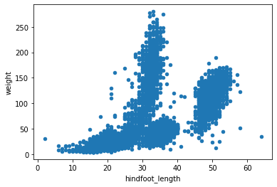

```python
my_plot = surveys.plot("hindfoot_length", "weight", kind="scatter")
my_plot
```

**Tip: When using Jupyter notebooks, we can make figures appear in-line within the notebook by executing.**

```python
%matplotlib inline
```

```python
type(my_plot)
```

```
matplotlib.axes._subplots.AxesSubplot
```

**Tip: Matplotlib itself can be overwhelming, so a useful strategy is to do as much as you easily can in a convenience layer, i.e. start creating the plot in Pandas or plotnine, and then use matplotlib for the rest.**

*We will cover a few basic commands for creating and formatting plots with matplotlib in this lesson. A great resource for help creating and styling your figures is the [matplotlib gallery](http://matplotlib.org/gallery.html), which includes plots in many different styles and the source codes that create them.*

#### plt pyplot versus object-based matplotlib

*Matplotlib integrates nicely with the NumPy package and can use NumPy arrays as input to the available plot functions.*

```python
import numpy as np
sample_data = np.random.normal(0, 0.1, 1000)
```

*To plot a histogram of our draws from the normal distribution, we can use the hist function directly.*

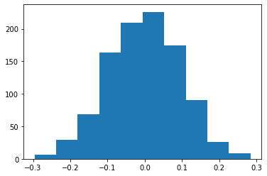

```python
plt.hist(sample_data)
```

**Tip: Cross-Platform Visualization of Figures** *Jupyter Notebooks make many aspects of data analysis and visualization much simpler. This includes doing some of the labor of visualizing plots for you. But, not every one of your collaborators will be using a Jupyter Notebook. The **.show()** command allows you to visualize plots when working at the command line, with a script, or at the IPython interpreter. In the previous example, adding **plt.show()** after the creation of the plot will enable your colleagues who aren’t using a Jupyter notebook to reproduce your work on their platform.*

*We can also create matplotlib figure and axis objects first and subsequently add a histogram with 30 data bins.*

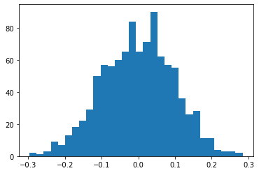

```python
fig, ax = plt.subplots() # initiate an empty figure and axis matplotlib object
ax.hist(sample_data, 30)
```

*Although the latter approach requires a little bit more code to create the same plot, the advantage is that it gives us full control over the plot and we can add new items such as labels, grid lines, title, and other visual elements. For example, we can add additional axes to the figure and customize their labels.*

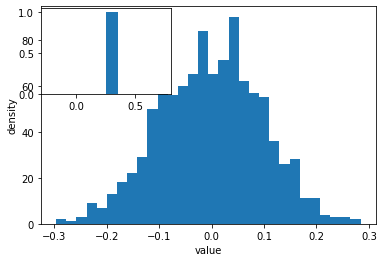

```python
fig, ax1 = plt.subplots() # prepare a matplotlib figure
ax1.hist(sample_data, 30)

# Add a plot of a Beta distribution
a = 5
b = 10
beta_draws = np.random.beta(a, b)

# adapt the labels
ax1.set_ylabel('density')
ax1.set_xlabel('value')

# add additional axes to the figure
ax2 = fig.add_axes([0.125, 0.575, 0.3, 0.3])
#ax2 = fig.add_axes([left, bottom, right, top])
ax2.hist(beta_draws)
```

**Challenge - Drawing from distributions** Have a look at numpy.random [documentation](https://numpy.org/doc/stable/reference/random/index.html). Choose a distribution you have no familiarity with, and try to sample from and visualize it.